# Air Pollutant Transport Along Lake Michigan

Benjamin Dorava, Sanjay Murali, Akshat Jain

## Introduction

Air pollution has detrimental impacts on community health, especially for vulnerable populations. Some of these impacts can be mitigated by issuing air quality advisories, which are informed by predictions of atmospheric flow.

High ozone concentrations resulting from specific wind patterns can exacerbate air pollution, contributing to respiratory issues and cardiovascular problems among residents. This study delves into the correlation between wind velocity and ozone levels by analyzing air quality monitoring data from a fixed location 40 miles north of downtown Chicago, and seeking to investigate possible correlations between wind velocity and ozone concentrations.

From our analysis comparing mean ozone concentrations between samples of similar wind velocity, we find that there is a positive correlation between north-westward blowing wind and ozone concentration.

## Background

One source of air pollutants—such as ozone and its precursors—is automobiles. The increased concentration of automobiles within cities predictably means that ozone concentrations are typically greater than in rural areas. This investigation is interested in the effects of wind as it transports ozone from urban towards rural areas.

The Wisconsin Department of Natural Resources maintains several air quality monitoring sites across the state. The data set we analyze consists of two consecutive years of seasonally reported ozone concentrations and meteorological conditions measured by the Chiwaukee Prairie Stateline station (AQS: 55-059-0019).

This station records hourly ozone concentrations during March through October, and data was available for 2021–2022.[^1] The station is located less than 1,000 feet from the shore of Lake Michigan in Pleasant Prairie, Kenosha, which is roughly 40 miles north of Chicago.[^2]

We are interested in 3 variables: zonal and meridional components of flow, and ozone concentration. The zonal (meridional) component of flow, conventionally written as $u$ ($v$) refers to the magnitude of the wind vector in the $\hat{i}$ ($\hat{j}$) direction; in other words, the portion of the wind blowing purely in the direction of west-to-east (south-to-north). These components of flow are determined trigonometrically from the reported wind speed and direction, and are in units of ${ms}^{-1}$. Ozone concentration is reported in units of parts per billion ($ppb$).

## Analysis

The first graphical summary of the data was simply of ozone concentrations plotted against components of wind velocity. Because the points are plotted against the velocity vector, each point can be thought of as the head of the wind vector, whose tail is the origin.

**Figure 1** shows how the Ozone concentration changes with respect to the wind velocity components. It uses each point as the head of a wind vector, from the origin.

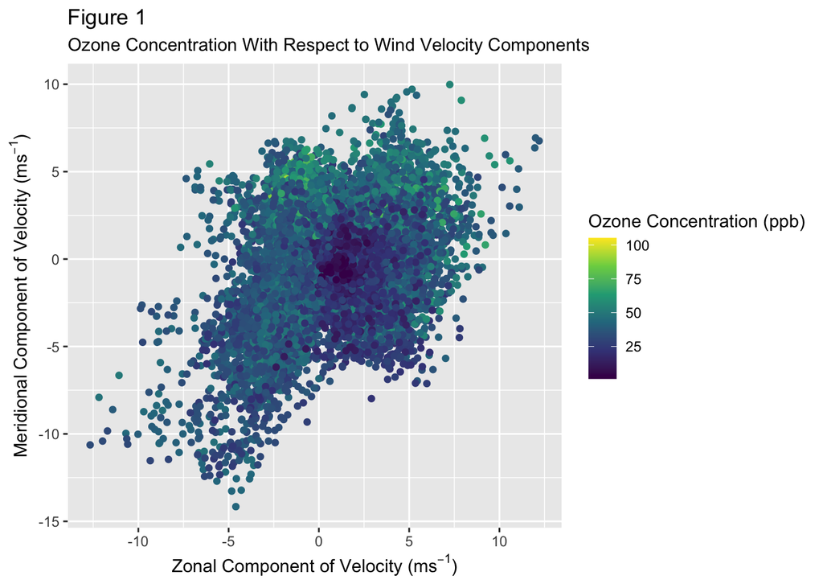

In the graph, we see the ozone concentration is lower in the origin, where winds would be more calm, are are higher towards to north and west components. However, there are too many individual points to make sense of, so in order to determine local statistics across the continuous data set, values were binned by rounding to the nearest whole ${ms}^{-1}$.

Bins with fewer than 30 members are not included, while outliers remain visible.

We have included annotations for the five regions we will compare:

- Gold: Calm wind, slightly skewed Eastward to account for prevailing wind
- Top-Left: North-westward wind
- Top-Right: North-eastward wind
- Bottom-Left: South-westward wind
- Bottom-Right: South-eastward wind

**Figure 2** shows how the Ozone concentration changes with respect to the wind velocity components. It uses bins by rounding values to the nearest whole ${ms}^{-1}$.

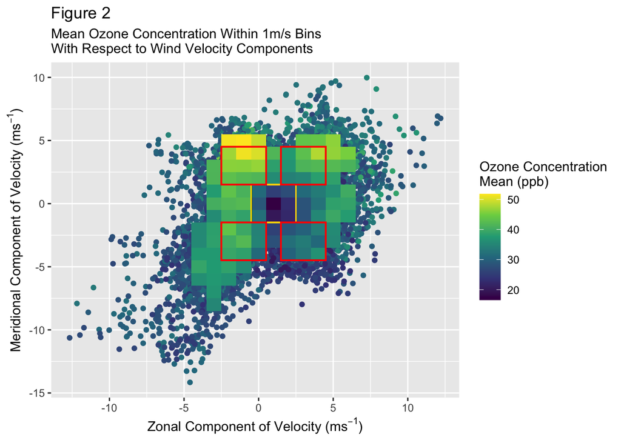

Observation and Initial Hypotheses Upon visual inspection, the region with calm winds (Gold) appears to have the lowest mean ozone concentration. Conversely, the Top-Left region, representing north-westward winds, shows the highest mean concentration. This initial observation suggests a potential correlation between wind direction and ozone levels.

Hypotheses:

Null Hypothesis ($H_0$): There is no significant difference in mean ozone concentrations between different wind velocity components.

Alternate Hypothesis ($H_a$): There is a significant difference in mean ozone concentrations between at least one pair of wind velocity components.

Perhaps most apparently, the region of calm wind has the lowest mean ozone concentration. This would suggest that at this site, ozone concentration is positively correlated with wind speed.

The Top-Left region appears to have a highest mean concentration. This would suggest that at this site, ozone concentration is positively correlated with wind blowing towards the north-west.

For each pair of adjacent quadrants, we conducted Welch’s t-tests to evaluate whether there is a significant difference in mean ozone concentrations. The results of these tests are as follows:

```
## [1] "< 2.22e-16"
```

```
## [1] "< 2.22e-16"
```

```
## [1] "< 2.22e-16"
```

```
## [1] "< 2.22e-16"
```

In summary, since the p values are very small (less than 2.2^10-16), the statistical tests support the alternate hypothesis, suggesting that there are significant differences in mean ozone concentrations between different wind velocity components. This finding reinforces the observed patterns in Figure 2, highlighting the influence of wind direction on ozone levels.

## Discussion

The analysis reveals a compelling correlation between wind direction and ozone levels, showcasing distinctive patterns across different quadrants. Thus, our hypothesis tests strongly suggest that the mean ozone levels are different in different across different regions, with the north-west region having the largest mean concentration of ozone. This suggests that ozone is being advected (transported) from the south-east (from Chicago). This is what we would expect, given that ozone is generally produced in urban areas.

To investigate the broader relationships of our data, examining the standard deviation of ozone concentrations across different flows may give us a few clues. In the same region of increased mean concentration, we see a larger standard deviation in the ozone concentrations carried by north-westward winds.

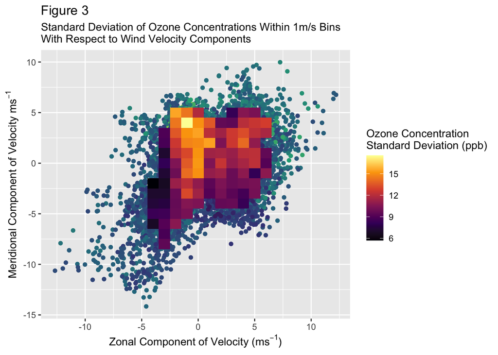

One possible physical explanation of this behavior is lake breeze. Lake breezes are an occasional coastward breeze marked by shifting winds and decreasing temperatures, and were the focus of researchers such as Wagner et al. (2022) during the 2017 Lake Michigan Ozone Study. Lake breeze events are sporadic, meaning that the wind may blow north-west even in the absence of a lake breeze. In these cases, considerably lower values of ozone concentration would be recorded than during lake breeze events. This is to say that if these increased levels of ozone are caused by these periodic and discrete lake breeze events, we would expect a notable variance between ozone concentrations. This is what we observe in **Figure 3**.

**Figure 4** shows a time series of a lake breeze event which occurred on 19 May 2022. Noting its temperature drops, shifting wind direction, and increased ozone levels, this example demonstrates the sporadic nature of these events. The variance in ozone concentrations during north-westward winds aligns with the expectation that a lake breeze event will correlates to increased ozone levels.

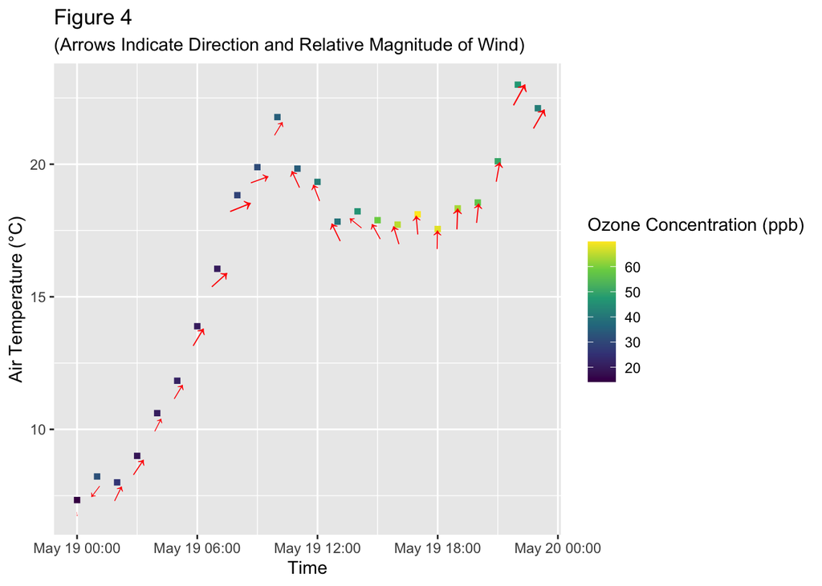

Further research could include an investigation into the meteorological conditions preceding a lake-breeze event, such as difference in air temperature above land and above water.

## References

Wagner T. J., Czarnetzki, A. C., Christiansen, M., Pierce, R. B., Stanier, C. O., Dickens, A. F., & Eloranta, E. W., 2022: Observations of the Development and Vertical Structure of the Lake-Breeze Circulation during the 2017 Lake Michigan Ozone Study. J. Atmos. Sci., 79, 1005–1020, DOI: 10.1175/JAS-D-20-0297.1

Wisconsin Department of Natural Resources, 2023: 2021 Chiwaukee Data. WDNR, accessed 7 November 2023, https://wi-dnr.widencollective.com/portals/iwvftorq/AirMonitoringData

Wisconsin Department of Natural Resources, 2023: 2022 Chiwaukee Data. WDNR, accessed 7 November 2023, https://wi-dnr.widencollective.com/portals/iwvftorq/AirMonitoringData

[^1]: https://wi-dnr.widencollective.com/portals/iwvftorq/iwvftorq/AirMonitoringData/c/feee5d04-93b9-4362-9e34-6e8ff5249c5a
[^2]: https://dnr.wisconsin.gov/sites/default/files/topic/AirQuality/Draft2024AnnualNetworkPlan.pdf